# Amostragem de Sinais Senoidais

Considere que você pretende desenvolver um sistema embarcado para fazer a avaliação da qualidade da energia elétrica analisando o sinal da tensão da rede de alimentação com técnicas de processamento digital de sinais.

Sabe-se que o sinal da tensão da rede de alimentação é (aproximadamente) senoidal e possui frequência de 60 Hz.

Considerando esses fatos, qual é a melhor **Taxa de Amostragem** a ser escolhida para esta tarefa?

Considere que este sinal possa ser descrito como:

$$x(t) = cos(2 \pi \cdot 60 \cdot t)$$

e o processo de amostragem consistem em realizar a seguinte operação:

$$x[n] = x_c(n \cdot Ts)$$

Portanto, o sinal discretizado terá a seguinte expressão:

$$x[n] = cos(2 \pi \cdot 60 \cdot n \cdot Ts)$$

```python
import numpy as np
import matplotlib.pyplot as plt
```

**1)** Faça uma simulação de forma a obter as 50 primeiras amostras deste sinal discretizado a uma Taxa de Amostragem de **1200 Hz**. Observe os resultados e faça suas considerações. Essa taxa é adequada?

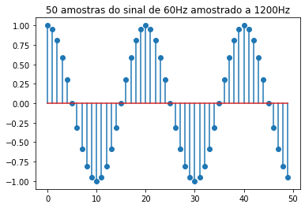

```python
# cria um vetor de inteiros [0 1 2 ... N] com comprimento de 50
n = np.arange(0, 50)

# frequencia de amostragem
fs = 1200
Ts = 1 / fs

# calcula as 50 primeiras amostras do sinal discretizado
x = np.cos(2*np.pi*60*n*Ts)

# plota o resultado
plt.stem(n, x)
plt.title('50 amostras do sinal de 60Hz amostrado a 1200Hz')
plt.show()
```

**Resp:**

**2)** Repita a mesma simulação anterior considerando, desta vez, **fs = 600 Hz**.

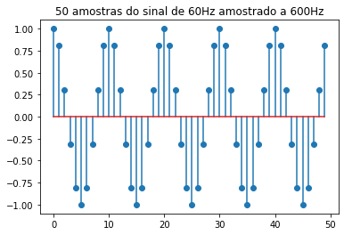

```python
# cria um vetor de inteiros [0 1 2 ... N] com comprimento de 50
n = np.arange(0, 50)

# frequencia de amostragem
fs = 600
Ts = 1 / fs

# calcula as 50 primeiras amostras do sinal discretizado
x = np.cos(2*np.pi*60*n*Ts)

# plota o resultado
plt.stem(n, x)
plt.title('50 amostras do sinal de 60Hz amostrado a 600Hz')
plt.show()
```

**3)** Repita a mesma simulação anterior considerando, desta vez, **fs = 120 Hz**.

Faça suas considerações.

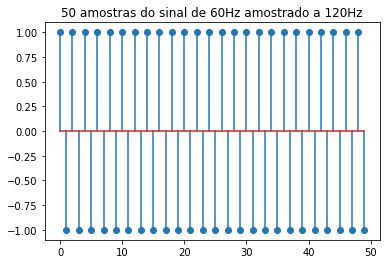

```python
# cria um vetor de inteiros [0 1 2 ... N] com comprimento de 50
n = np.arange(0, 50)

# frequencia de amostragem
fs = 120
Ts = 1 / fs

# calcula as 50 primeiras amostras do sinal discretizado
x = np.cos(2*np.pi*60*n*Ts)

# plota o resultado
plt.stem(n, x)
plt.title('50 amostras do sinal de 60Hz amostrado a 120Hz')
plt.show()
```

**Resp**:Com uma frequencia de 120 Hz ainda é possivel perceber que se trata de um sinal sinusoidal devido a inversão dos sinais dos pontos subsequentes.

**4)** Repita a mesma simulação anterior considerando, desta vez, **fs = 63 Hz**.

Faça suas considerações.

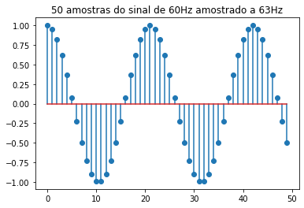

```python
# cria um vetor de inteiros [0 1 2 ... N] com comprimento de 50
n = np.arange(0, 50)

# frequencia de amostragem
fs = 63
Ts = 1 / fs

# calcula as 50 primeiras amostras do sinal discretizado
x = np.cos(2*np.pi*60*n*Ts)

# plota o resultado
plt.stem(n, x)
plt.title('50 amostras do sinal de 60Hz amostrado a 63Hz')
plt.show()
```

**Resp**: Com a frequncia de 63Hz observa-se que o número de amostras por periodo do sinal é inferior a 2, de modo que quando reconstruimos o sinal através do gráfico, percebemos que uma onde totalmente gdiferente, gerando um novo sinal que não representa o sinal original.

**5)** Na sua opinião, qual é a melhor Taxa de Amostragem a ser adotada para este tipo de projeto?

Existe algum inconveniente em adotar Taxas de Amostragens muito elevadas?

**Resp**: Nesse caso como se tratra de uma grandeza com apspecto rápido de alteração, quanto maior for a frequência maior resolução do sinal teremos para avaliar alterações nos valores de tensão, porém com uma frequência de 120Hz já é adequdo para fazer a análise do sinal.

Submeta pelo AVA:

- Notebook no formato .ipynb
- Notebook no formato .html

# Dados do aluno

**Nome**: Filipe Borato

**Matrícula**: 1521840